# Exploring space launches process

Exploring space launches process Mathilde Mousset 23 janvier 2019

This week, I decided to try the [#Tidytuesday](https://github.com/rfordatascience/tidytuesday)twitter challenge. Every week, [Thomas Mock](https://twitter.com/thomas_mock?lang=en) provides a mostly clean dataset for the community to analyse. Past datasets have covered a variety of subjects, from New York restaurant grades to tweets from the #rstat hashtag. These datasets provide excellent opportunities for everybody to try their hands on new data.

[This week’s dataset](https://github.com/rfordatascience/tidytuesday/tree/master/data/2019/2019-01-15) was data about space launches across the world. There was one table about agencies responsible for the launches, and a table about the launches. This data was associated with an [article from The Economist](https://www.economist.com/graphic-detail/2018/10/18/the-space-race-is-dominated-by-new-contenders), with a truly beautiful infographics.

I watched part of [Dave Robinson’s](https://t.co/5rBN2FPeB1) video on [how it tackled this](https://www.youtube.com/watch?v=ZyPrP_Yo1BA). To be honest, I have not yet finished watching it, because I was so earnest to try some of the data cleaning tricks he showed that I began coding after half of it. But I will watch the rest, to see what else he did.

**New tools I wanted to learn:**

- the `countrycode` package, to go from country codes to full names,
- Some functions from the `forcats` package. I have use this package before, but I had never used the `fct_collapse` and `fct_lump` functions.

# Preparing the data

I focused mostly on the `launches` table. It was already tidy, so I did not perform great reshaping. However, I wanted to tweak some columns a bit.

```r
# Get better date format in lauches
launches <- launches %>%
  mutate(launch_date  = ymd(launch_date),
         launch_month = month(launch_date,
                                label =  TRUE,
                                abb = FALSE),
         launch_weekday  = weekdays(launch_date),
         launch_week_num = week(launch_date))
```

I then tried to improve the country names. Some of the code are familiar, some are not, I had to do a little search.

```
##  [1] "BR"     "CN"     "CYM"    "F"      "I"      "I-ELDO" "I-ESA"
##  [8] "IL"     "IN"     "IR"     "J"      "KP"     "KR"     "RU"
## [15] "SU"     "UK"     "US"
```

I used the `countrycode` package to obtain the full names of the countries. Since the `countrycode()` function takes ISO codes, I manually changed the provided code to ISO code when necessary. I also collapsed the Soviet Union and current Russia into a Russia state.

The `fct_collapse` function allowed us to collapse the levels of a factor into a new level. Here I collapsed SU and RU into RU for example, and changed the name of some factors.

```r
launches$state_code_clean <- fct_collapse(launches$state_code,
    "RU" = c("SU", "RU"),
    "FR" = c("F", "I-ELDO", "I-ESA"),
    "JP" = "J",
    "IT" = "I",
    "KY" = "CYM",
    "GB" = "UK")
```

Now that I made sure that all my country codes follow the ISO2c norm, I can use the `countrycode` function to obtain the full country names.

```r
launches$state_name <- countrycode(launches$state_code_clean,
                                   "iso2c",
                                   "country.name")

launches$state_name %>% unique() %>% kable()
```

| x |
| --- |
| United States |
| France |
| Brazil |
| China |
| Italy |
| Russia |
| Iran |
| Israel |
| Japan |
| India |
| South Korea |
| North Korea |
| United Kingdom |
| Cayman Islands |

Sweet.

Now, that we have some human-readable names, let’s have a look at how many launches each country performed.

```r
launches %>%
  count(state_name, sort = TRUE) %>% kable()
```

| state_name | n |
| --- | --- |
| Russia | 3178 |
| United States | 1716 |
| France | 307 |
| China | 302 |
| Japan | 115 |
| India | 65 |
| Israel | 10 |
| Italy | 9 |
| Iran | 8 |
| North Korea | 5 |
| Cayman Islands | 4 |
| South Korea | 3 |
| Brazil | 2 |
| United Kingdom | 2 |

We can see that there is a big drop between India and Israel. I will follow Dave Robinson lead here and create a variable with the six first countries, and pool the rest in “Others”. To do this, I use the `fct_lump` function.

```r
launches <- launches %>%
  mutate(state_name_short = fct_lump(state_name, 6)) %>%
  replace_na(list(state_name_short = "Other"))
```

Personally, I also like the idea of pooling countries by geographical area. It does not change much for the state and Russia, but I think it helps having a better picture about Europe and Asia.

I also change the levels of the `category` column to make them more understandable.

```r
launches <- launches %>%
  mutate(state_bloc = fct_collapse(state_code_clean,
                                   "URSS"   = "RU",
                                   "Europe" = c("FR", "IT", "GB", "KY"),
                                   "North_america"     = "US",
                                   "Asia"   = c("CN", "JP", "IN", "KR", "KP"),
                                   "South_america" = "BR",
                                   "Middle_east" = c("IR", "IL")))  %>%
  mutate(category = fct_recode(category,
                                Success = "O",
                                Failure = "F"))
```

# Lauches per geographic area and states

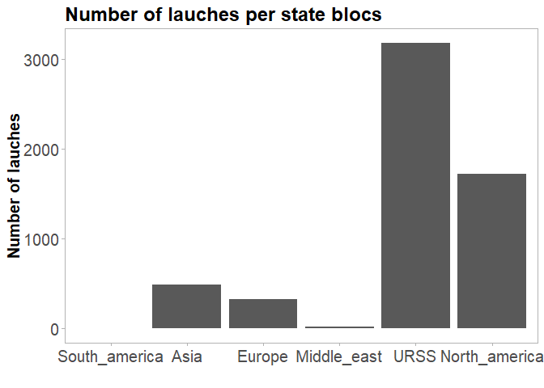

```r
launches %>%
  count(state_bloc, sort = TRUE) %>%
  ggplot(aes(x = state_bloc, y = n)) +
  geom_bar(stat = "identity") +
  labs(title = "Number of lauches per state blocs",
       x = "",
       y = "Number of lauches") +
   theme(panel.grid = element_blank(),
        strip.text = element_text(face = "bold")) +
  my_theme
```

Let’s have a look at the launches across time per country.

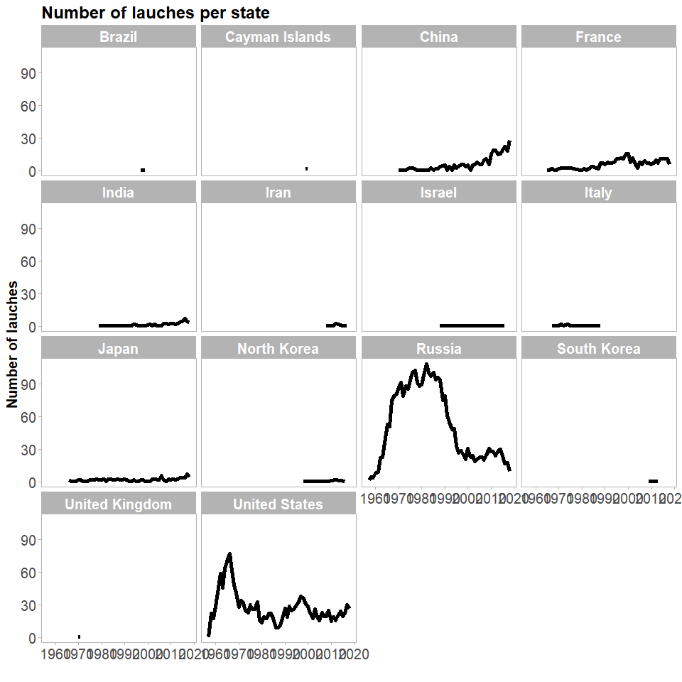

```r
launches %>%
  count(launch_year, state_name, state_bloc) %>%
  ggplot(aes(x = launch_year, y = n)) +
  geom_line(size = 2) +
  labs(title = "Number of lauches per state",
       x = "",
       y = "Number of lauches") +
  facet_wrap(~state_bloc, scales = "free") +
  facet_wrap(~state_name) +
  theme(panel.grid = element_blank(),
        strip.text = element_text(face = "bold")) +
   scale_x_continuous("", breaks = seq(1960, 2020, 10)) +
  my_theme
```

It is not bad, but I will use the shortened list of country as Dave Robinson did to make comparisons between countries easier.

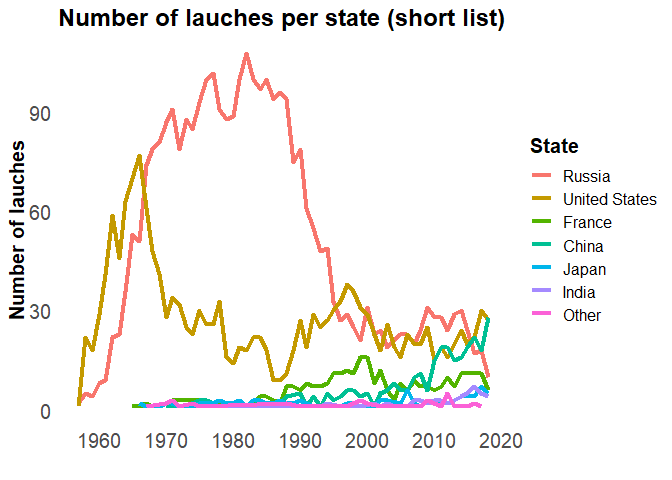

```r
launches %>%
  count(state_name_short, launch_year) %>%
  mutate(state_name_short = fct_reorder(state_name_short, -n, sum)) %>%
  ggplot(aes(x = launch_year, y = n,
             colour = state_name_short)) +
  geom_line(size = 1.5) +
  labs(title = "Number of lauches per state (short list)",
       x = "Year of launch",
       y = "Number of lauches",
       colour = "State") +
  theme_minimal() +
   theme(panel.grid = element_blank(),
        strip.text = element_text(face = "bold")) +
   scale_x_continuous("", breaks = seq(1960, 2020, 10)) +
  my_theme
```

Lets have a look with the geographical blocs.

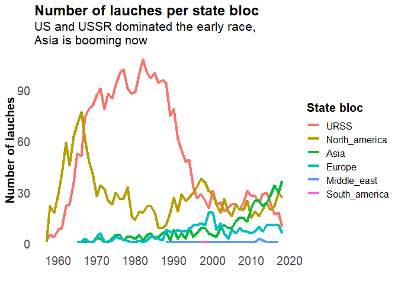

```r
launches %>%
  count(state_bloc, launch_year) %>%
  mutate(state_bloc = fct_reorder(state_bloc, -n, sum)) %>%
  ggplot(aes(x = launch_year, y = n,
             colour = state_bloc)) +
  geom_line(size = 1.5) +
  labs(title = "Number of lauches per state bloc",
       subtitle = "US and USSR dominated the early race, \nAsia is booming now",
       x = "Year of launch",
       y = "Number of lauches",
       colour = "State bloc") +
  theme_minimal() +
  theme(panel.grid = element_blank()) +
   scale_x_continuous("", breaks = seq(1960, 2020, 10)) +
  my_theme
```

I like how it is easier to see what’s happening in Asia.

# US vs Russia

Since for a long time the race was dominated by the US and Russia, let’s have a nice comparison graph between the two.

[figure not shown]

```r
launches %>%
  filter(state_name %in% c("United States", "Russia")) %>%
   ggplot(aes(x = launch_year, fill = state_name)) +
  geom_area(stat = "bin",
            position = "identity",
            bins = 30, alpha = 0.6) +
  scale_fill_manual(values = c("#999999", "#E69F00")) +
    theme_minimal() +
  theme(panel.grid = element_blank(),
        strip.text = element_text(face = "bold")) +
  labs(title = "Space race: US vs Russia",
       subtitle = "Numer of launches per year in Russia and \nthe states",
       x = "Year of launches ",
       y = "Number of launches",
       fill = "") +
   scale_x_continuous("", breaks = seq(1960, 2020, 10)) +
  my_theme
```

# Success vs Failure

We have the information on whether the launch was a success or a failure. let’s have a look at how the number of failures evolved though time.

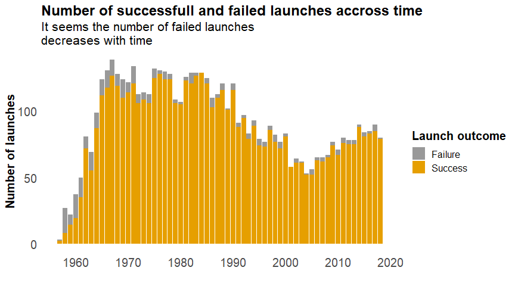

```r
launches %>%
  count(category, launch_year) %>%
  ggplot(aes(x = launch_year, y = n,
             fill = category)) +
  geom_bar(stat = "identity",
            #position = "identity",
            ) +
  scale_fill_manual(values = c("#999999", "#E69F00")) +
    theme_minimal() +
  theme(panel.grid = element_blank(),
        strip.text = element_text(face = "bold")) +
  labs(title = "Number of successfull and failed launches accross time",
       subtitle = "It seems the number of failed launches \ndecreases with time",
       x = "Year of launches ",
       y = "Number of launches",
       fill = "Launch outcome") +
  scale_x_continuous("", breaks = seq(1960, 2020, 10)) +
  my_theme
```

Sweet. Let’s have a look by country, focusing on the countries that send most launches.

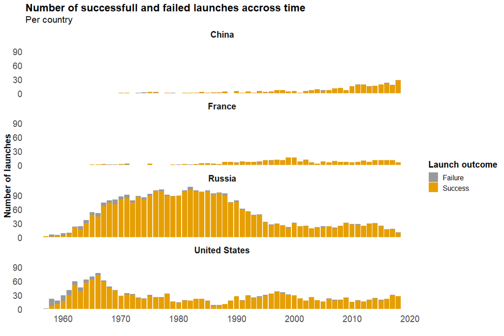

```r
launches %>%
  filter(state_name %in% c("China", "France", "Russia", "United States")) %>%
  count(category, launch_year, state_name_short) %>%
  ggplot(aes(x = launch_year, y = n,
             fill = category)) +
  geom_bar(stat = "identity") +
  facet_wrap(~state_name_short, nrow = 4) +
  scale_fill_manual(values = c("#999999", "#E69F00")) +
    theme_minimal() +
  theme(panel.grid = element_blank(),
        strip.text = element_text(face = "bold")) +
  labs(title = "Number of successfull and failed launches accross time",
       subtitle = "Per country",
       x = "Year of launches ",
       y = "Number of launches",
       fill = "Launch outcome") +
  scale_x_continuous("", breaks = seq(1960, 2020, 10)) +
  my_theme
```

It’s nice, but I would have to have a look at the proportion of failed launches.

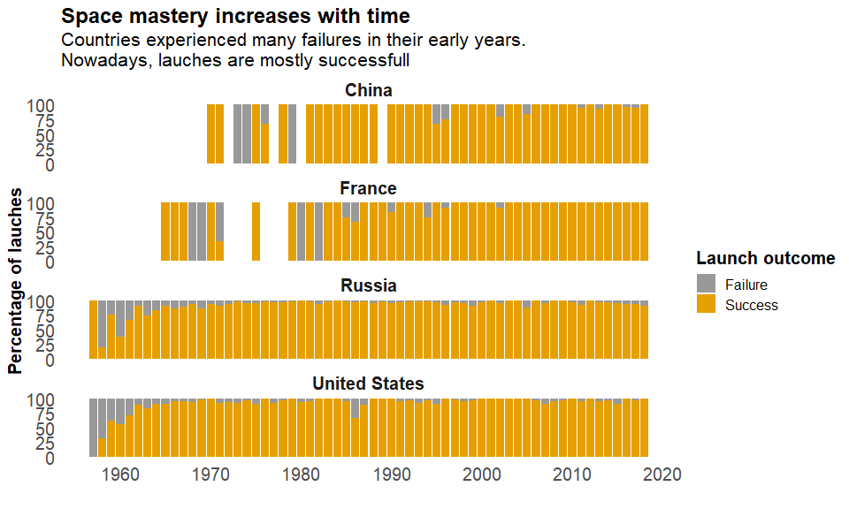

```r
launches %>%
  filter(state_name %in% c("China", "France", "Russia", "United States")) %>%
  group_by(state_name, launch_year) %>%
  add_tally() %>%
  add_count(category) %>%
  distinct(state_bloc, launch_year, category, n, nn) %>%
  mutate(proportion = nn / n) %>%
  ggplot(aes(x = launch_year, y = proportion*100,
             fill = category)) +
  geom_bar(stat = "identity") +
  facet_wrap(~state_name, nrow = 4) +
  labs(title = "Space mastery increases with time",
       subtitle = "Countries experienced many failures in their early years. \nNowadays, lauches are mostly successfull",
       x = "Year of launch",
       y = "Percentage of lauches",
       fill = "Launch outcome") +
  scale_fill_manual(values = c("#999999", "#E69F00")) +
    theme_minimal() +
  theme_minimal() +
   theme(panel.grid = element_blank(),
        strip.text = element_text(face = "bold")) +
  scale_x_continuous("", breaks = seq(1960, 2020, 10)) +
  my_theme
```

# Private vs public lauches

Now I wanted to see whether the launches were mostly made by states or by private companies, and how this varied with time.

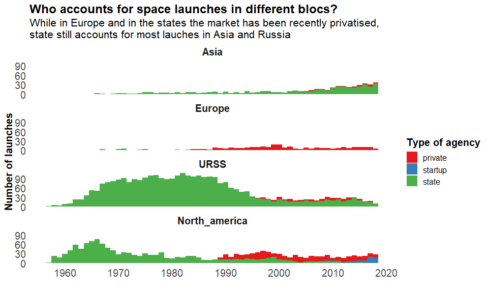

```r
launches %>%
  filter(state_bloc != "South_america" & state_bloc != "Middle_east") %>%
  ggplot(aes(x = launch_year, fill = agency_type) ) +
  geom_histogram(bins = 62) +
  facet_wrap(vars(state_bloc), nrow = 4) +
  theme_minimal() +
  theme(panel.grid = element_blank(),
        strip.text = element_text(face = "bold")) +
    scale_fill_brewer(palette = "Set1") +
  labs(title = "Who accounts for space launches in different blocs?",
       subtitle = "While in Europe and in the states the market has been recently privatised, \nstate still accounts for most lauches in Asia and Russia",
       x = "Year of launch",
       y = "Number of launches",
       fill = "Type of agency") +
   scale_x_continuous("", breaks = seq(1960, 2020, 10)) +
  my_theme
```

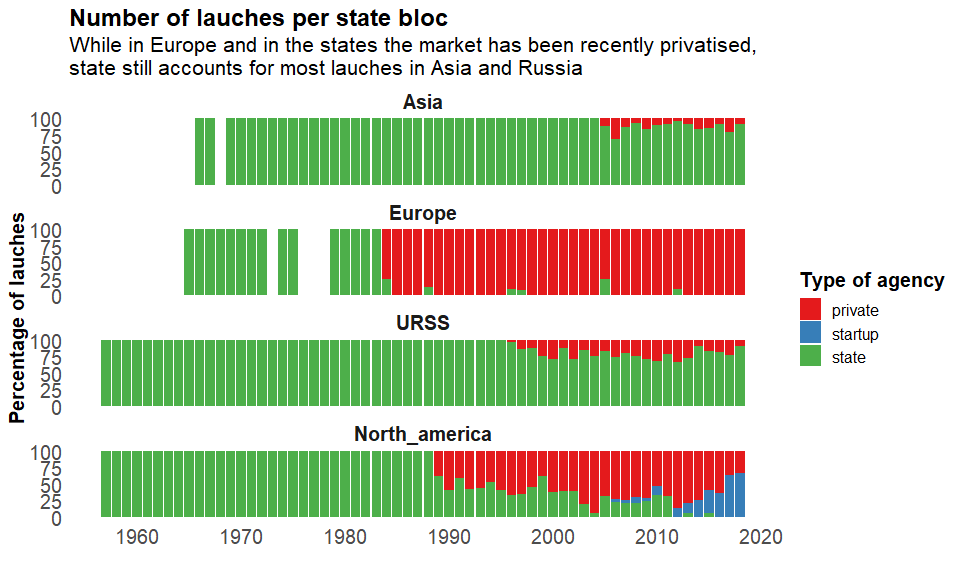

```r
launches %>%
  filter(state_bloc != "South_america" & state_bloc != "Middle_east") %>%
  select(state_bloc, launch_year, agency_type) %>%
  group_by(state_bloc, launch_year) %>%
  add_tally() %>%
  add_count(agency_type) %>%
  distinct(state_bloc, launch_year, agency_type, n, nn) %>%
  mutate(proportion = nn / n) %>%
  ggplot(aes(x = launch_year, y = proportion*100,
             fill = agency_type)) +
  geom_bar(stat = "identity") +
  facet_wrap(~state_bloc, nrow = 4) +
  labs(title = "Number of lauches per state bloc",
       subtitle = "While in Europe and in the states the market has been recently privatised, \nstate still accounts for most lauches in Asia and Russia",
       x = "Year of launch",
       y = "Percentage of lauches",
       fill = "Type of agency") +
  scale_fill_brewer(palette = "Set1") +
  theme_minimal() +
   theme(panel.grid = element_blank(),
        strip.text = element_text(face = "bold")) +
   scale_x_continuous("", breaks = seq(1960, 2020, 10)) +
  my_theme
```

# Date of launches

Since the data is so huge, I focus on an early period of the space exploration, and on the past decade.

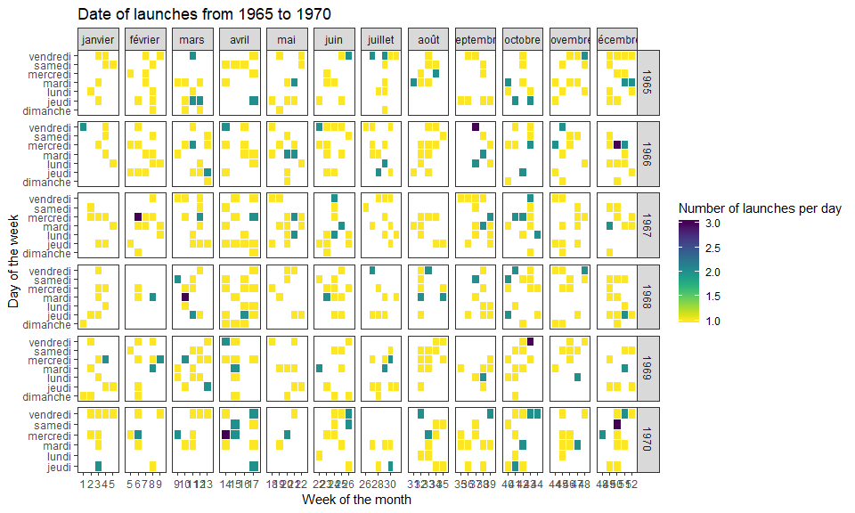

```r
launches %>%
  drop_na(launch_month, launch_week_num, launch_weekday, launch_year) %>%
  filter(launch_year %in% c(1965:1970)) %>%
  count(launch_year, launch_month,
        launch_weekday, launch_week_num) %>%
  ggplot(aes(x = launch_week_num,
             y = launch_weekday)) +
  geom_tile(aes(fill = n),colour = "white", na.rm = TRUE) +
  facet_grid(vars(launch_year), vars(launch_month),
             scale = "free") +
  scale_fill_viridis(option = "viridis",
                     direction = -1) +
  #scale_fill_gradient(low="red", high="yellow") +
  theme_bw() +
  labs(title = "Date of launches from 1965 to 1970",
       x = "Week of the month",
       y = "Day of the week",
       fill = "Number of launches per day") +
  theme(panel.grid.major = element_blank(),
        panel.grid.minor = element_blank())
```

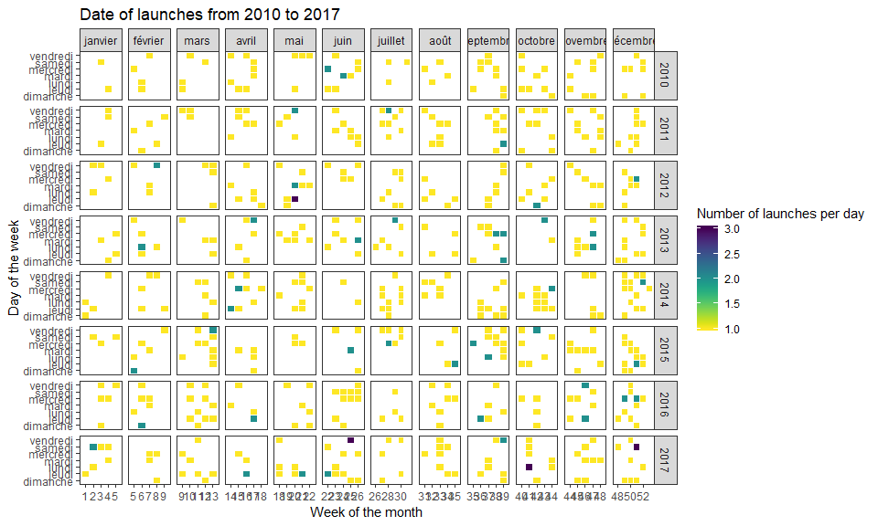

```r
launches %>%
  drop_na(launch_month, launch_week_num, launch_weekday, launch_year) %>%
  filter(launch_year %in% c(2010:2017)) %>%
  count(launch_year, launch_month,
        launch_weekday, launch_week_num) %>%
  ggplot(aes(x = launch_week_num,
             y = launch_weekday)) +
  geom_tile(aes(fill = n),colour = "white", na.rm = TRUE) +
  facet_grid(vars(launch_year), vars(launch_month),
             scale = "free") +
  scale_fill_viridis(option = "viridis",
                     direction = -1) +
  theme_bw() +
  labs(title = "Date of launches from 2010 to 2017",
       x = "Week of the month",
       y = "Day of the week",
       fill = "Number of launches per day") +
  theme(panel.grid.major = element_blank(),
        panel.grid.minor = element_blank())
```